# Análisis

## Series de tiempo con su tendencia

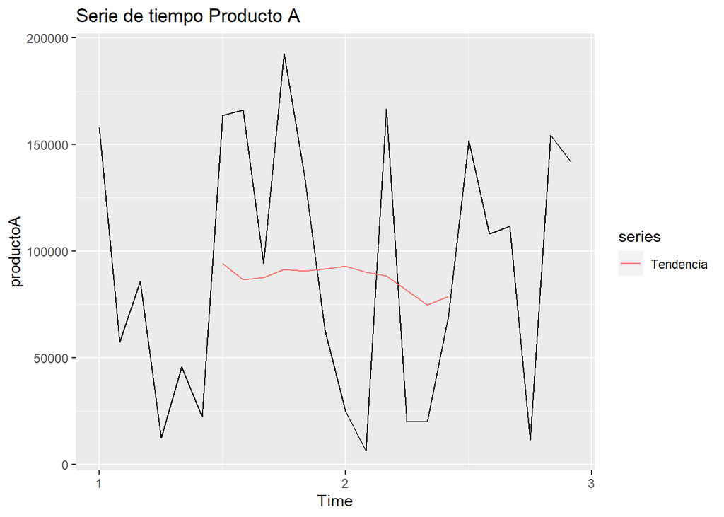

```r
autoplot(productoA)+autolayer(trendcycle(productoA.ts.desc),series="Tendencia")+labs(title="Serie de tiempo Producto A")
```

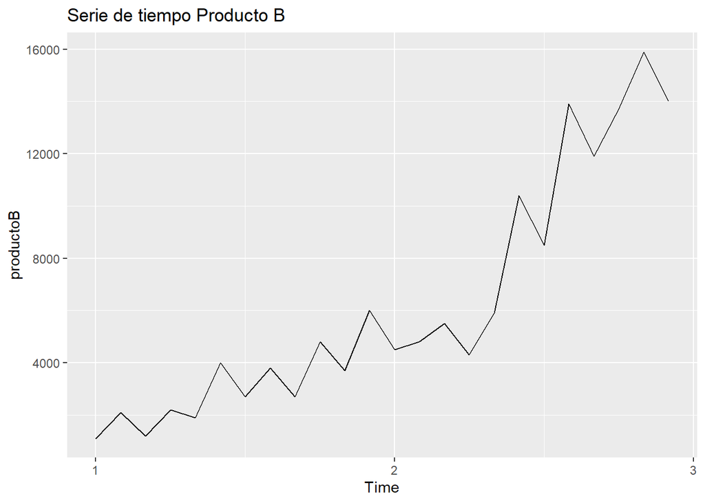

```r
autoplot(productoB)+labs(title="Serie de tiempo Producto B")
```

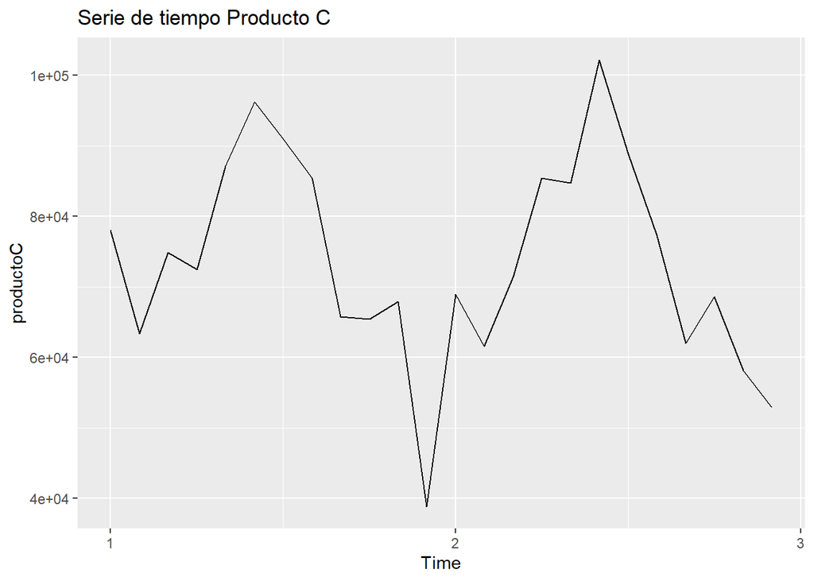

```r
autoplot(productoC)+labs(title="Serie de tiempo Producto C")
```

### Gráficas desestacionadas

Si eliminamos la componente estacional y dejamos la componente de tendencia y el ruidp, obtenemos:

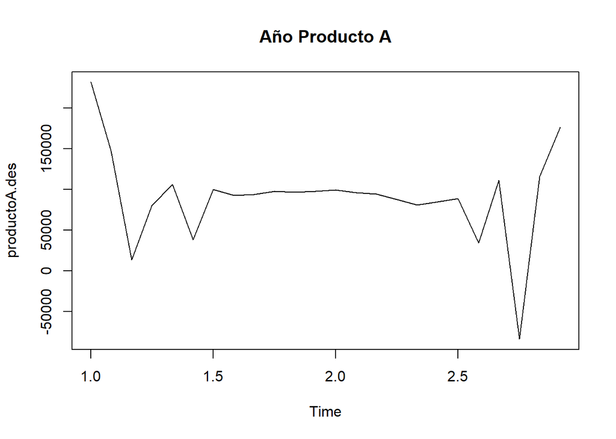

```r
productoA.des = productoA-productoA.ts.desc$seasonal
plot(productoA.des,main="Año Producto A")
```

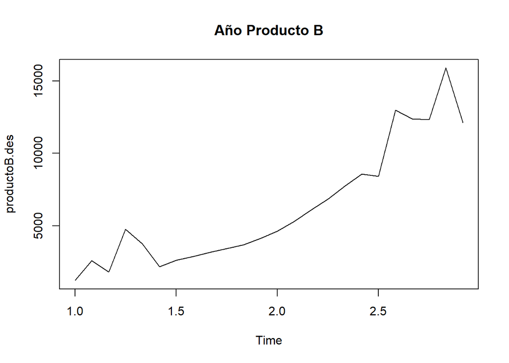

```r
productoB.des = productoB-productoB.ts.desc$seasonal
plot(productoB.des,main="Año Producto B")
```

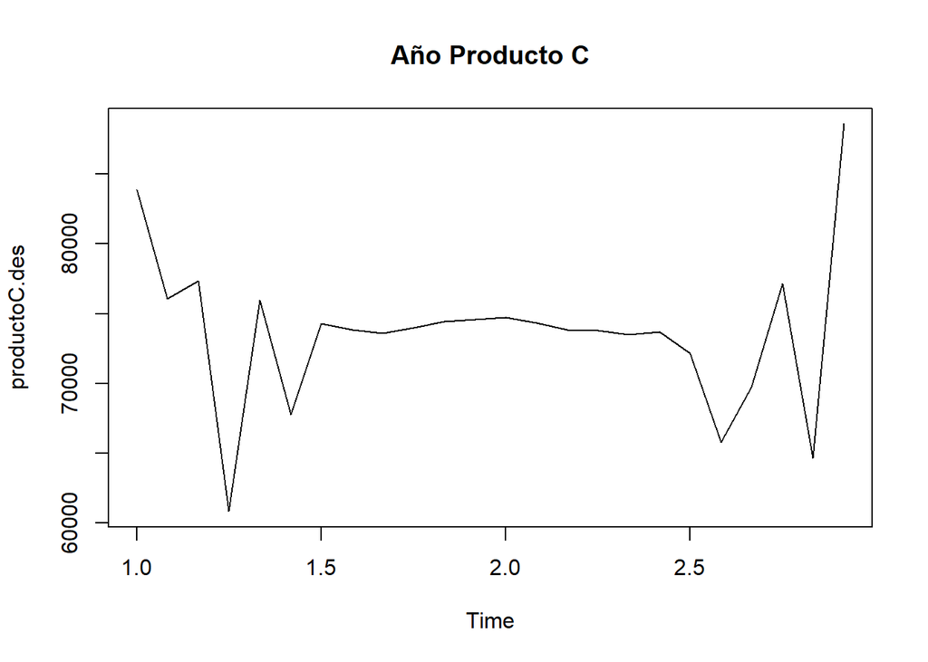

```r
productoC.des = productoC-productoC.ts.desc$seasonal
plot(productoC.des,main="Año Producto C")
```

## Transformación de la serie original

### 1. Estabilización de la varianza

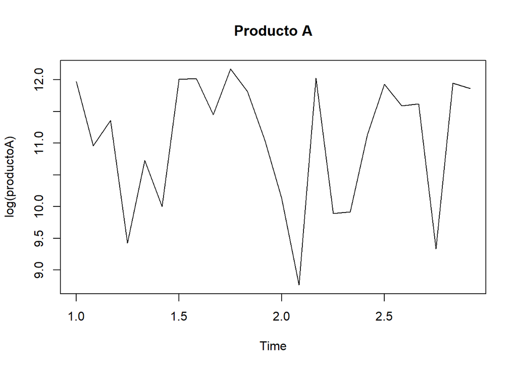

```r
plot(log(productoA),main="Producto A")
```

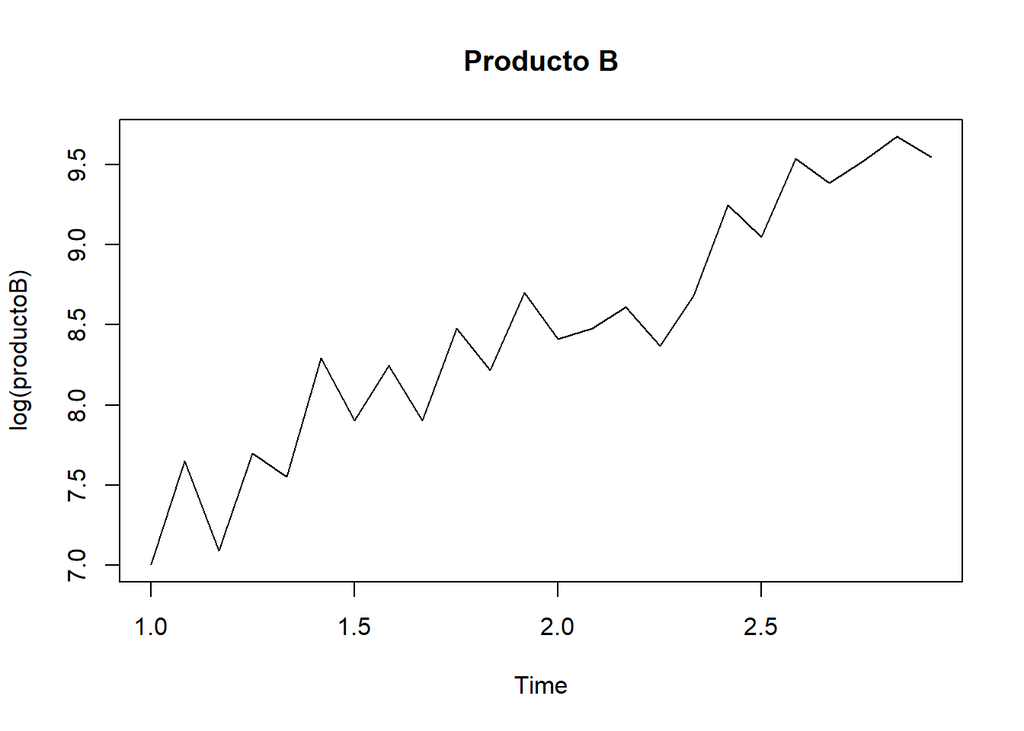

```r
plot(log(productoB),main="Producto B")
```

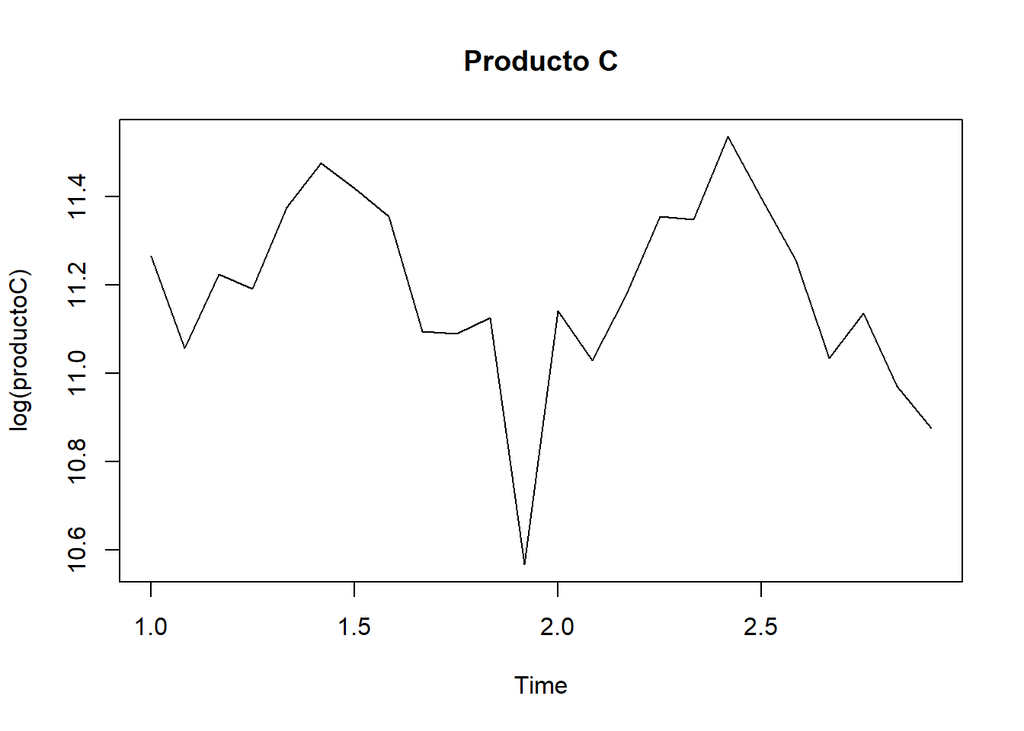

```r
plot(log(productoC),main="Producto C")
```

### 2. Eliminación de tendencia

Para esto diferenciamos la serie; o sea, consideramos la serie de diferencias entre una observación y la anterior en lugar de la serie original.

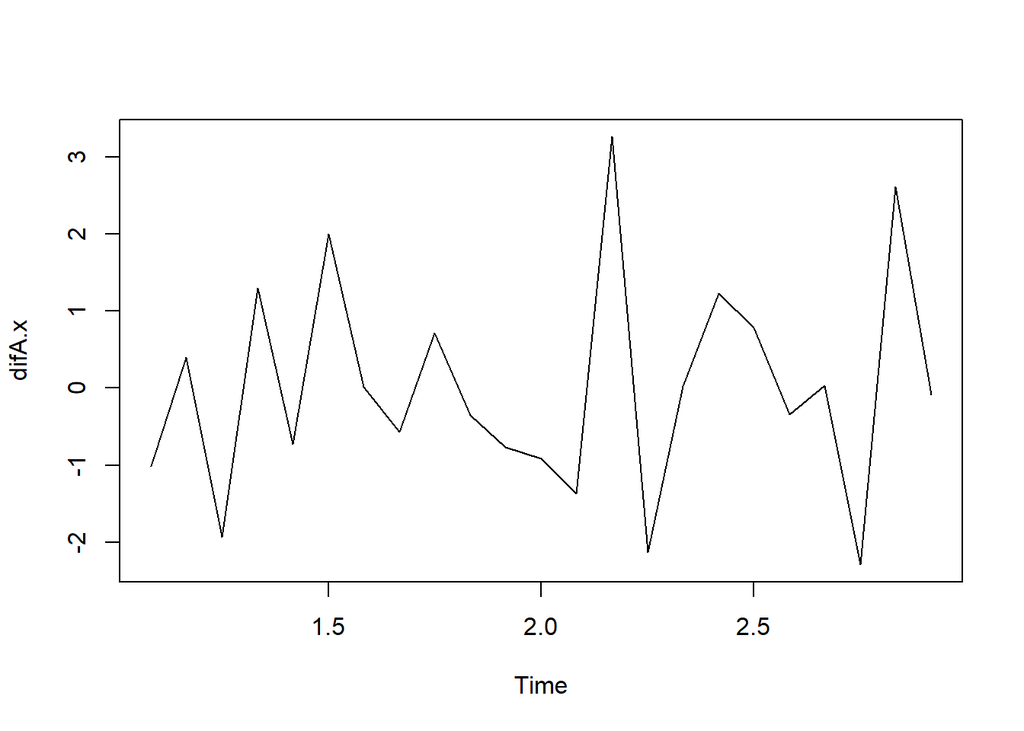

```r
x = log(productoA); difA.x = diff(x); plot(difA.x)
```

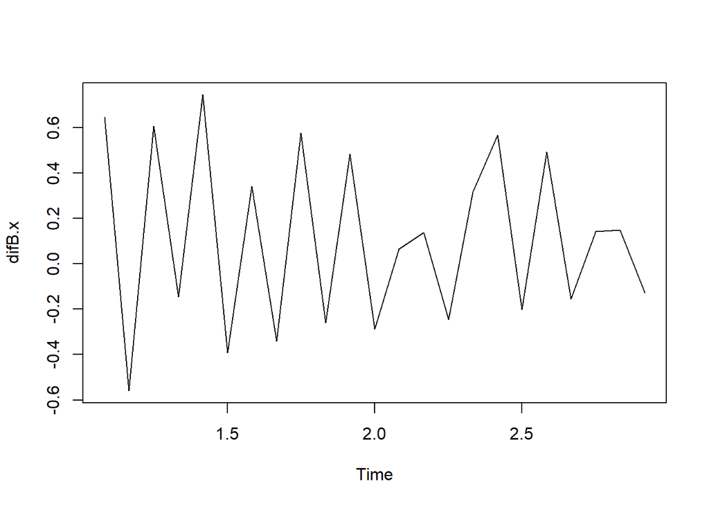

```r
x = log(productoB); difB.x = diff(x); plot(difB.x)
```

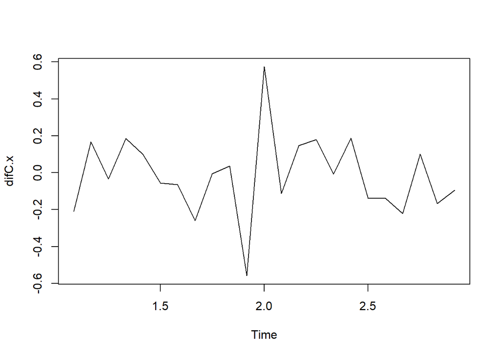

```r
x = log(productoC); difC.x = diff(x); plot(difC.x)
```

### 3. Eliminación de estacionalidad

Para eliminar la estacionalidad de una serie mensual se pueden tomar diferencias estacionales de orden 12, como se muestra a continuación:

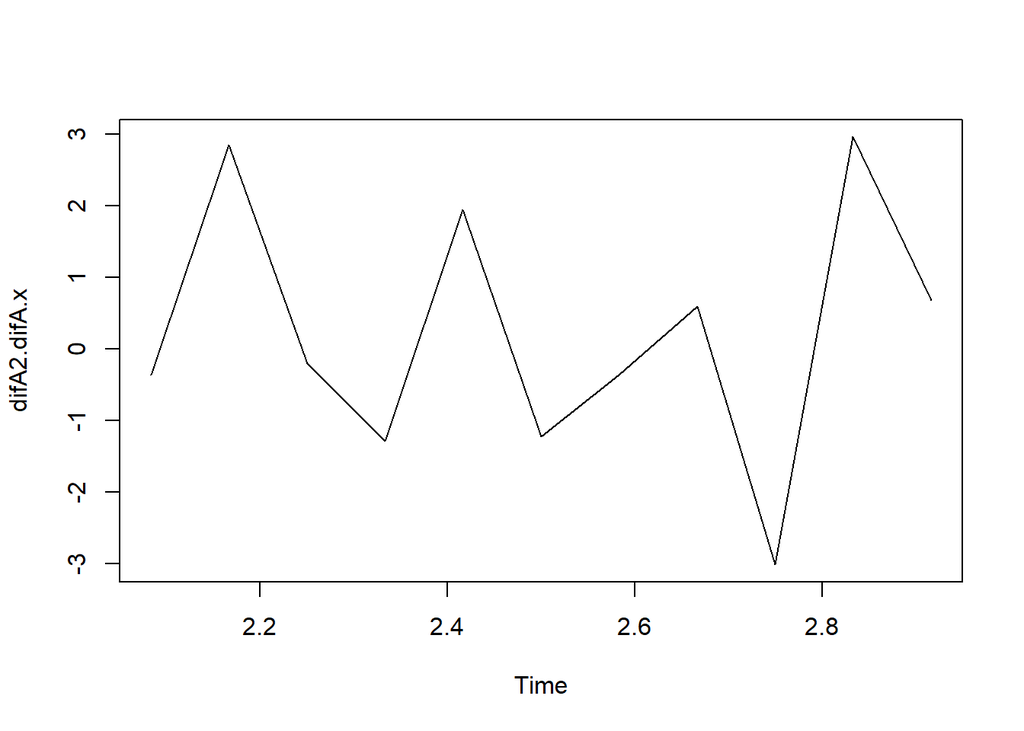

```r
difA2.difA.x = diff(difA.x,lag=12); plot(difA2.difA.x)
```

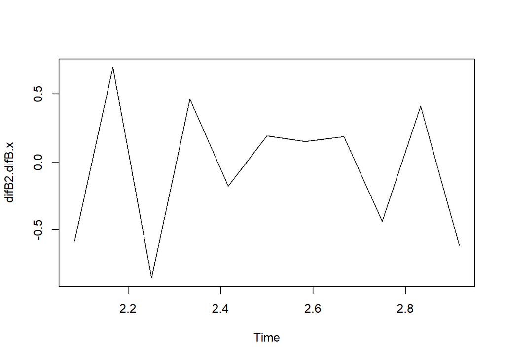

```r
difB2.difB.x = diff(difB.x,lag=12); plot(difB2.difB.x)
```

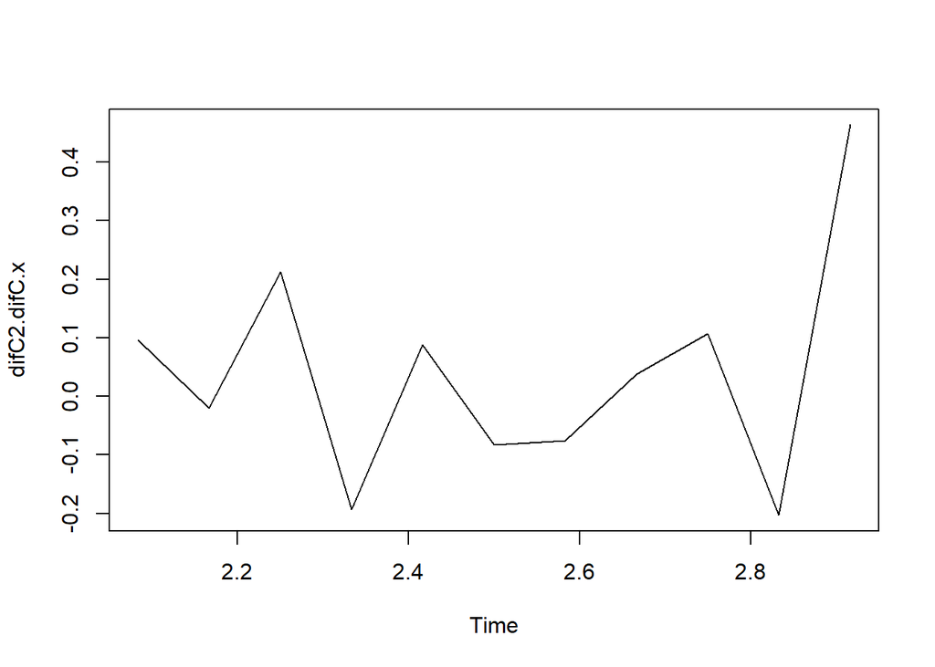

```r
difC2.difC.x = diff(difC.x,lag=12); plot(difC2.difC.x)
```

## Funciones de autocovarianzas y de autocorrelaciones

Representación del correlograma de la serie:

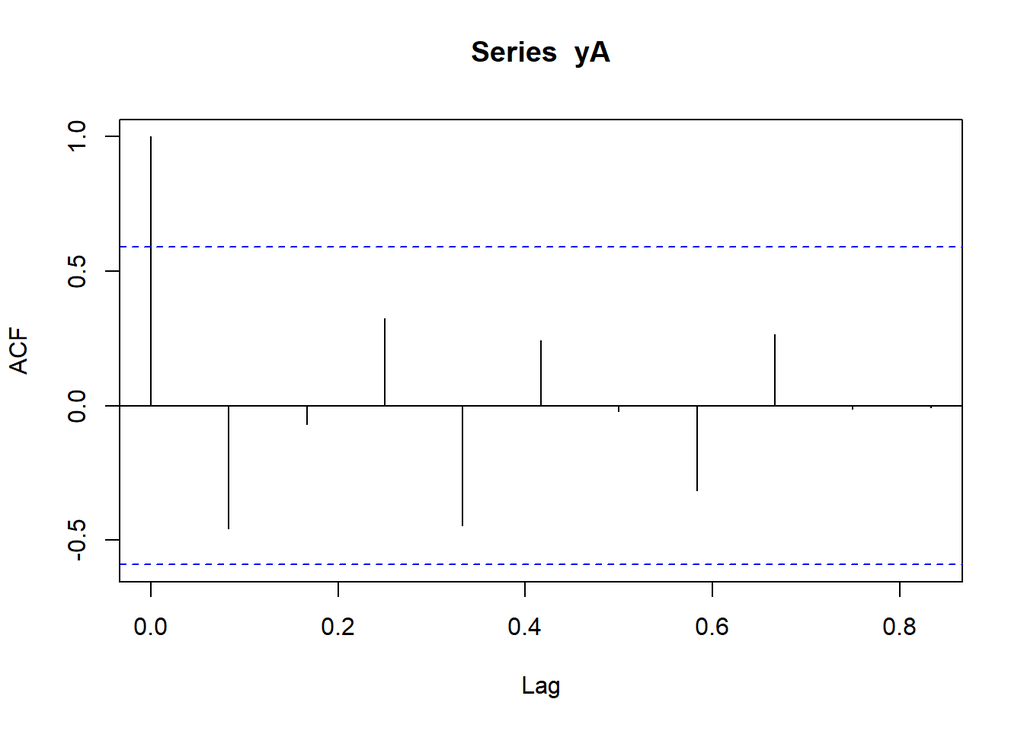

```r
# FUNCIONES DE AUTOCOVARIANZAS Y DE AUTOCORRELACIONES
yA = difA2.difA.x; acf(yA)
```

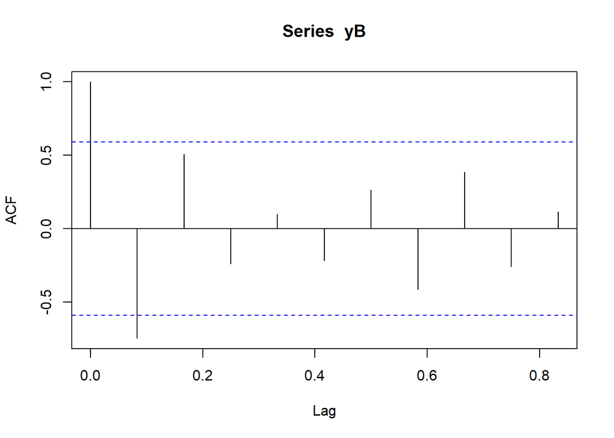

```r
yB = difB2.difB.x; acf(yB)
```

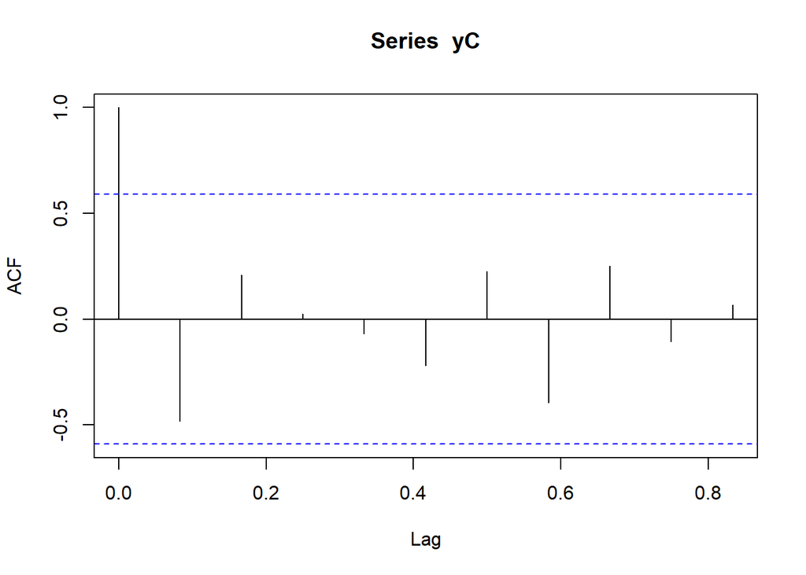

```r
yC = difC2.difC.x; acf(yC)
```

Donde las líneas punteadas representan las bandas de confianza, bajo la hipótesis de que la serie es un ruido blanco(no correlacionada).

### Valores numéricos de las correlaciones estimadas:

```r
# Valores numéricos
acf(yA,plot=FALSE)$acf
```

```
## , , 1
##
##               [,1]
##  [1,]  1.000000000
##  [2,] -0.457686003
##  [3,] -0.069101667
##  [4,]  0.323164169
##  [5,] -0.445899037
##  [6,]  0.242276736
##  [7,] -0.019865149
##  [8,] -0.316750729
##  [9,]  0.265801788
## [10,] -0.014051842
## [11,] -0.007888266
```

```r
acf(yB,plot=FALSE)$acf
```

```
## , , 1
##
##              [,1]
##  [1,]  1.00000000
##  [2,] -0.74573461
##  [3,]  0.50748725
##  [4,] -0.24002799
##  [5,]  0.09909055
##  [6,] -0.21614750
##  [7,]  0.26458387
##  [8,] -0.41277209
##  [9,]  0.38453400
## [10,] -0.25578391
## [11,]  0.11477042
```

```r
acf(yC,plot=FALSE)$acf
```

```
## , , 1
##
##              [,1]
##  [1,]  1.00000000
##  [2,] -0.48371893
##  [3,]  0.20878097
##  [4,]  0.02363753
##  [5,] -0.06982729
##  [6,] -0.21942818
##  [7,]  0.22605977
##  [8,] -0.39633863
##  [9,]  0.25126817
## [10,] -0.10644168
## [11,]  0.06600827
```

# PRONÓSTICO

Para realizar un pronóstico, decidimos utilizar el modelo estadístico ARIMA. Al no contar con valores p, d,q utilizamos auto.arima(), que nos brinda el mejor modelo a utilizar.

```r
auto.arima(productoA,trace=T) # (0,0,0)
```

```
##
##  ARIMA(2,0,2)            with non-zero mean : Inf
##  ARIMA(0,0,0)            with non-zero mean : 601.1741
##  ARIMA(1,0,0)            with non-zero mean : 603.5883
##  ARIMA(0,0,1)            with non-zero mean : 603.5594
##  ARIMA(0,0,0)            with zero mean     : 627.1432
##  ARIMA(1,0,1)            with non-zero mean : 606.4575
##
##  Best model: ARIMA(0,0,0)            with non-zero mean
```

```
## Series: productoA
## ARIMA(0,0,0) with non-zero mean
##
## Coefficients:
##           mean
##       90933.33
## s.e.  12348.23
##
## sigma^2 = 3.819e+09:  log likelihood = -298.3
## AIC=600.6   AICc=601.17   BIC=602.96
```

```r
auto.arima(productoB,trace=T) # (1,1,0)
```

```
##
##  ARIMA(2,1,2)            with drift         : Inf
##  ARIMA(0,1,0)            with drift         : 419.1688
##  ARIMA(1,1,0)            with drift         : 410.2179
##  ARIMA(0,1,1)            with drift         : 414.171
##  ARIMA(0,1,0)                               : 418.5257
##  ARIMA(2,1,0)            with drift         : 413.127
##  ARIMA(1,1,1)            with drift         : 413.1542
##  ARIMA(2,1,1)            with drift         : 416.3143
##  ARIMA(1,1,0)                               : 414.5579
##
##  Best model: ARIMA(1,1,0)            with drift
```

```
## Series: productoB
## ARIMA(1,1,0) with drift
##
## Coefficients:
##           ar1     drift
##       -0.6355  596.2183
## s.e.   0.1581  197.8724
##
## sigma^2 = 2546880:  log likelihood = -201.48
## AIC=408.95   AICc=410.22   BIC=412.36
```

```r
auto.arima(productoC,trace=T) # (1,0,0)
```

```
##
##  ARIMA(2,0,2)            with non-zero mean : Inf
##  ARIMA(0,0,0)            with non-zero mean : 532.2195
##  ARIMA(1,0,0)            with non-zero mean : 526.4324
##  ARIMA(0,0,1)            with non-zero mean : 529.174
##  ARIMA(0,0,0)            with zero mean     : 609.1537
##  ARIMA(2,0,0)            with non-zero mean : 529.2105
##  ARIMA(1,0,1)            with non-zero mean : 529.2842
##  ARIMA(2,0,1)            with non-zero mean : 532.1736
##  ARIMA(1,0,0)            with zero mean     : 532.4383
##
##  Best model: ARIMA(1,0,0)            with non-zero mean
```

```
## Series: productoC
## ARIMA(1,0,0) with non-zero mean
##
## Coefficients:
##          ar1       mean
##       0.5562  72910.486
## s.e.  0.1711   5264.889
##
## sigma^2 = 156472987:  log likelihood = -259.62
## AIC=525.23   AICc=526.43   BIC=528.77
```

```r
arimaA <- arima(productoA,order=c(0,0,0));
arimaB <- arima(productoB,order=c(1,1,0));
arimaC <- arima(productoC,order=c(1,0,0));
```

## Suavizamiento y pronóstico

```r
library(smooth)
pA.2 <- sma(productoA,order=4,h=4,silent=FALSE)
```

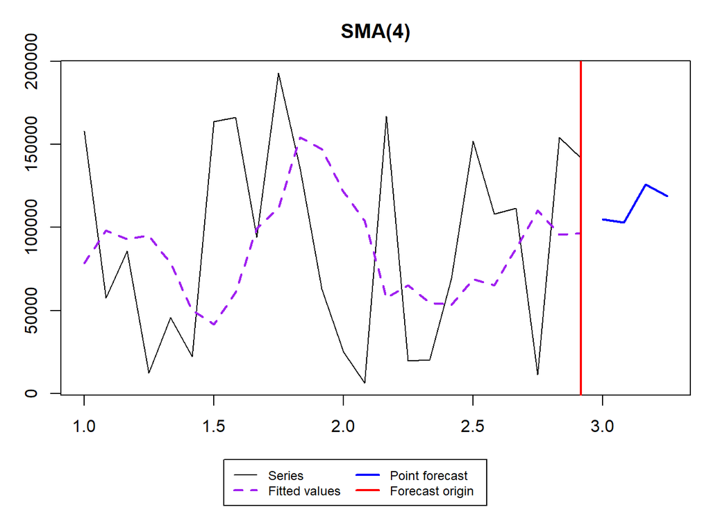

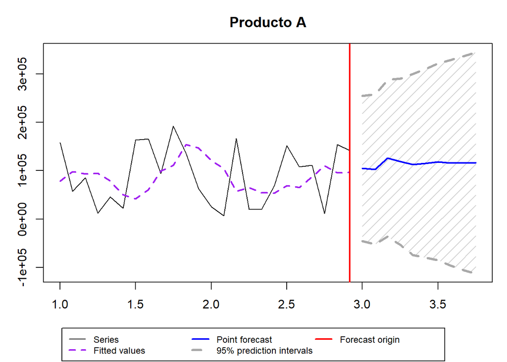

```r
pA <- forecast(pA.2); plot(pA,main="Producto A")
```

```r
pB.2 <- sma(productoB,order=4,h=4,silent=FALSE)
```

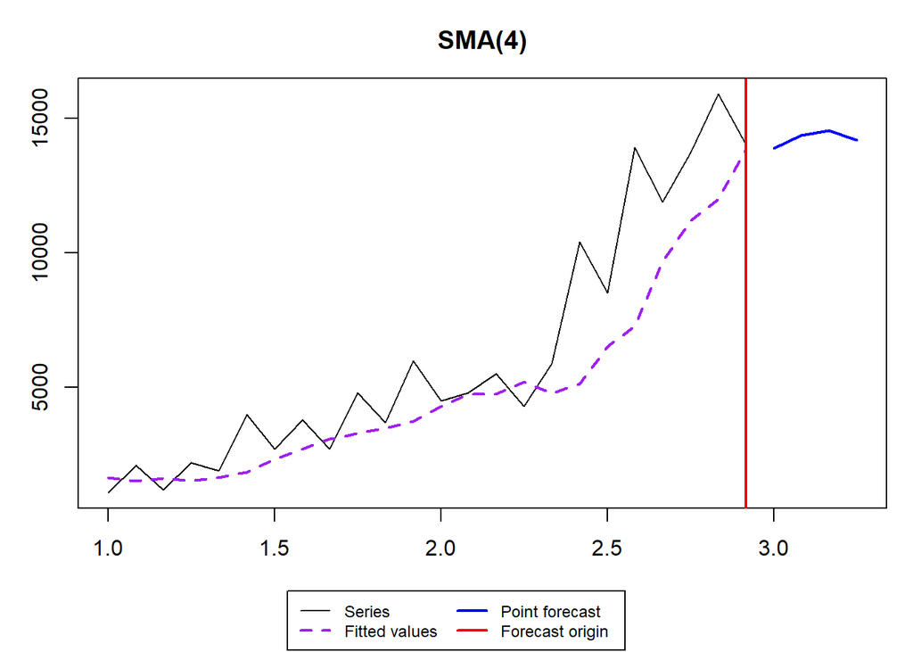

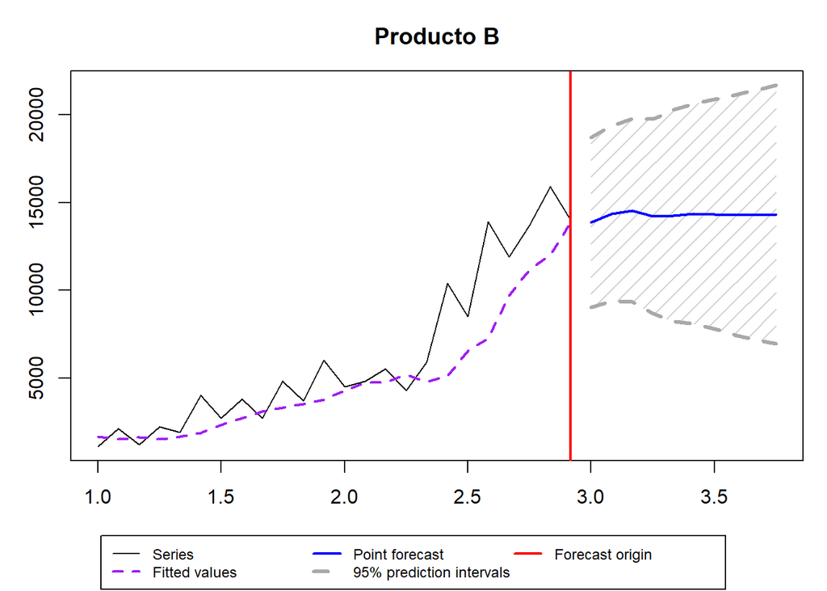

```r
pB <- forecast(pB.2); plot(pB,main="Producto B")
```

```r
pC.2 <- sma(productoC,order=4,h=4,silent=FALSE)
```

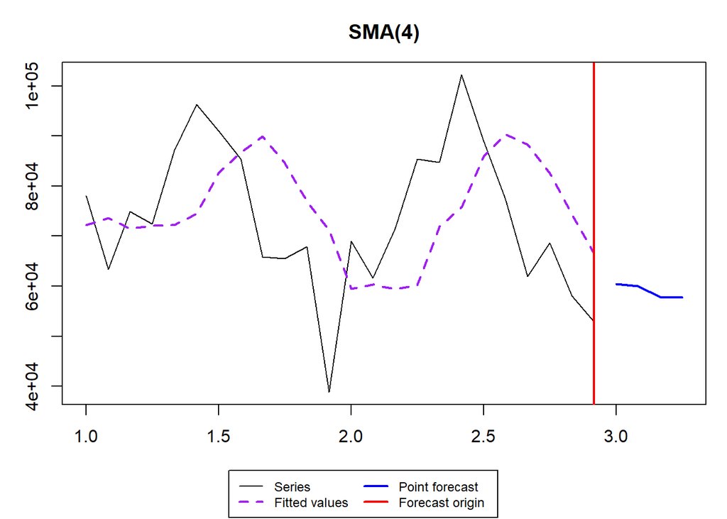

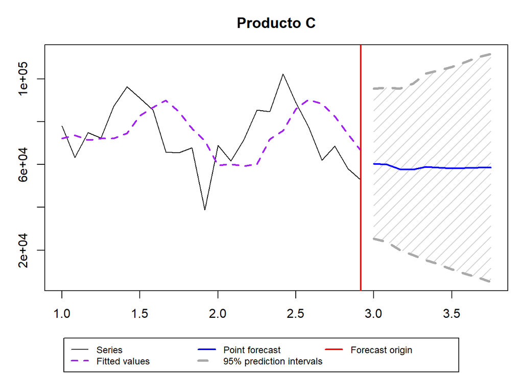

```r
pC <- forecast(pC.2); plot(pC,main="Producto C")
```